# Dual-number verification — is the bottom Arabic the right page?

**173** pages have an Arabic volume page (verify the big **p.N** matches the BOTTOM crop). **86** are corrections (orange) where the old Roman-only read was different — these matter most. Also 100 pages are Roman/section-only (no Arabic volume found; not shown here).

p.119 volume (arabic, bottom) was 21 → 119

TOP

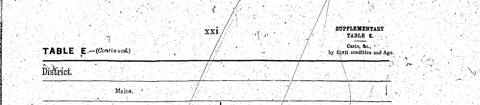

BOTTOM

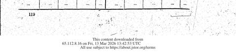

section(roman top)=21 · top=xxi(roman) · bottom=119(arabic) · data_table

08059088d0a859fee8891a6f4a5d2957ba20face.png

p.188 volume (arabic, bottom) was 90 → 188

TOP

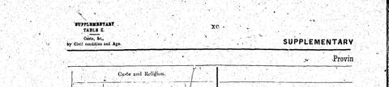

BOTTOM

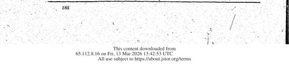

section(roman top)=90 · top=XC(roman) · bottom=188(arabic) · data_table

0826a46f0b9688a3f91af5cf04a0a5431bcfd2fc.png

p.421 volume (arabic, bottom) was 7 → 421

TOP

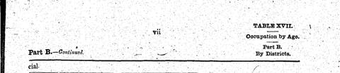

BOTTOM

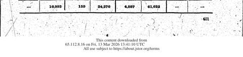

section(roman top)=7 · top=vii(roman) · bottom=421(arabic) · data_table

06b61414557b054821931b44c09490c2fac64469.png

p.323 volume (arabic, bottom) was 225 → 323

TOP

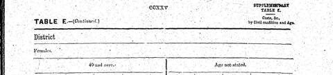

BOTTOM

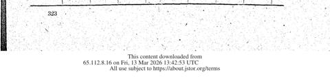

section(roman top)=225 · top=CCXXV(roman) · bottom=323(arabic) · data_table

091f80325a20211693e60a5dea7dcc8eb2404917.png

p.200 volume (arabic, bottom) was 102 → 200

TOP

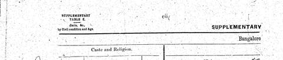

BOTTOM

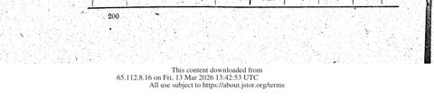

section(roman top)=102 · top=cii(roman) · bottom=200(arabic) · data_table

1fbccfb3916ced62021aea21d3a44e577d266d6d.png

p.184 volume (arabic, bottom) was 86 → 184

TOP

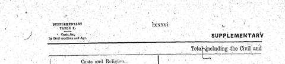

BOTTOM

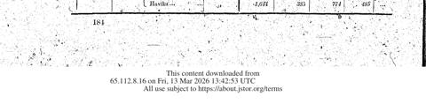

section(roman top)=86 · top=lxxxvi(roman) · bottom=184(arabic) · data_table

128bc003d9d8c7cb84f65de0b1d6c49d0eef506c.png

p.192 volume (arabic, bottom) was 94 → 192

TOP

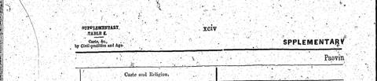

BOTTOM

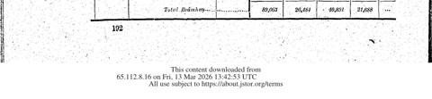

section(roman top)=94 · top=xciv(roman) · bottom=192(arabic) · data_table

0f3318c416e2b702ea52fa3e9919f1f0082e8a8a.png

p.509 volume (arabic, bottom) was 95 → 509

TOP

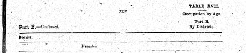

BOTTOM

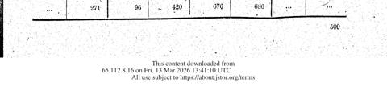

section(roman top)=95 · top=xcv(roman) · bottom=509(arabic) · data_table

31578f6a88fe8e01b1ce1fe84de37b20ae0f255d.png

p.190 volume (arabic, bottom) was 92 → 190

TOP

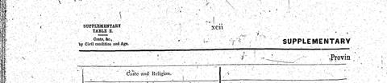

BOTTOM

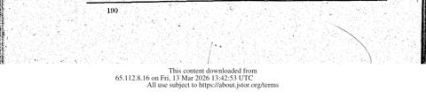

section(roman top)=92 · top=xcii(roman) · bottom=190(arabic) · data_table

307244b7a72f146ce66fafcb9e72875e95cf3e60.png

p.107 volume (arabic, bottom) was 55 → 107

TOP

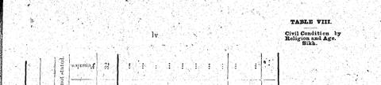

BOTTOM

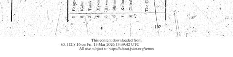

section(roman top)=55 · top=lv(roman) · bottom=107(arabic) · data_table

3021ddc372634451b07724d26f2b9381b8235968.png

p.180 volume (arabic, bottom) was 82 → 180

TOP

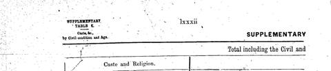

BOTTOM

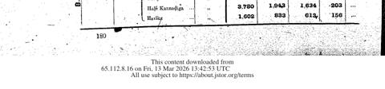

section(roman top)=82 · top=lxxxii(roman) · bottom=180(arabic) · data_table

30e98e44b6f1eb3409572a2b6784fe5ca8980aa3.png

p.450 volume (arabic, bottom) was 36 → 450

TOP

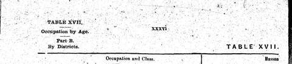

BOTTOM

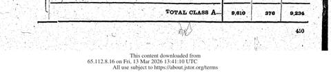

section(roman top)=36 · top=xxxvi(roman) · bottom=450(arabic) · data_table

2b6d54ec45c8748b571ac5e701bbdab6ae07af09.png

p.420 volume (arabic, bottom) was 6 → 420

TOP

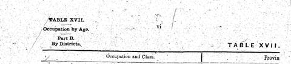

BOTTOM

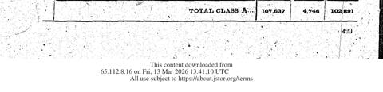

section(roman top)=6 · top=vi(roman) · bottom=420(arabic) · data_table

2dd7703ef32881347bdd87074732472566cd6e65.png

p.203 volume (arabic, bottom) was 105 → 203

TOP

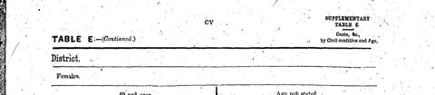

BOTTOM

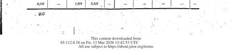

section(roman top)=105 · top=CV(roman) · bottom=203(arabic) · data_table

2a0b20624c2b9e0579ef5006db4a2c3cabfc4700.png

p.109 volume (arabic, bottom) was 57 → 109

TOP

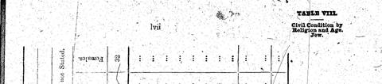

BOTTOM

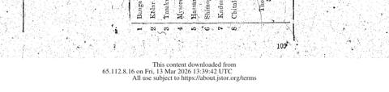

section(roman top)=57 · top=lvii(roman) · bottom=109(arabic) · data_table

41ae9d7f6451cfb44805a1c9e563402c7dc631c0.png

p.128 volume (arabic, bottom) was 30 → 128

TOP

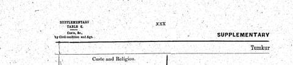

BOTTOM

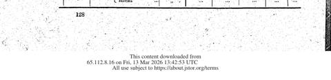

section(roman top)=30 · top=xxx(roman) · bottom=128(arabic) · data_table

40ec4a4773c63dd3c9042c4241d34ab713f06f8e.png

p.320 volume (arabic, bottom) was 4 → 320

TOP

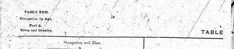

BOTTOM

[figure not shown]

section(roman top)=4 · top=iv(roman) · bottom=320(arabic) · data_table

4255a5e1c81b5a90884954edd2aec0077e2ae141.png

p.116 volume (arabic, bottom) was 64 → 116

TOP

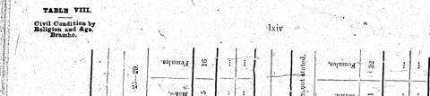

BOTTOM

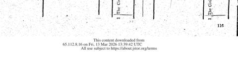

section(roman top)=64 · top=lxiv(roman) · bottom=116(arabic) · data_table

49736689c09280a801211019df0187d90ef44233.png

p.204 volume (arabic, bottom) was 106 → 204

TOP

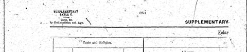

BOTTOM

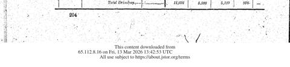

section(roman top)=106 · top=cvi(roman) · bottom=204(arabic) · data_table

4c3c8e46458eb43c28ae64916932e4162067bddb.png

p.185 volume (arabic, bottom) was 87 → 185

TOP

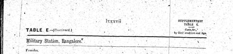

BOTTOM

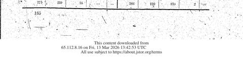

section(roman top)=87 · top=lxxxvii(roman) · bottom=185(arabic) · data_table

4e2cfc885994000e7d0a640e3799e2097beaa4ae.png

p.224 volume (arabic, bottom) was 126 → 224

TOP

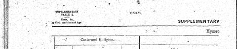

BOTTOM

[figure not shown]

section(roman top)=126 · top=CXXVI(roman) · bottom=224(arabic) · data_table

53090a680fef9e8a0ba97144101480ca77384fc7.png

p.113 volume (arabic, bottom) was 61 → 113

TOP

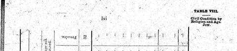

BOTTOM

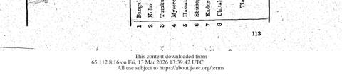

section(roman top)=61 · top=lxi(roman) · bottom=113(arabic) · data_table

5386b7741ca4c4b24e06add73f7d38ee9cc752aa.png

p.331 volume (arabic, bottom) was 15 → 331

TOP

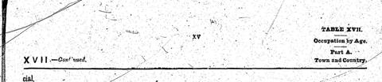

BOTTOM

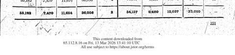

section(roman top)=15 · top=xv(roman) · bottom=331(arabic) · data_table

541445d278d6fe70d2935f9f71745581b925aefb.png

p.201 volume (arabic, bottom) was 103 → 201

TOP

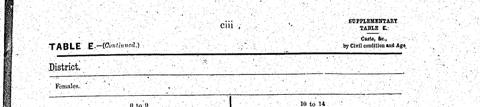

BOTTOM

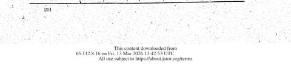

section(roman top)=103 · top=ciii(roman) · bottom=201(arabic) · data_table

5cb6757014cb6aedf196b7288b3b90852c1a5719.png

p.505 volume (arabic, bottom) was 91 → 505

TOP

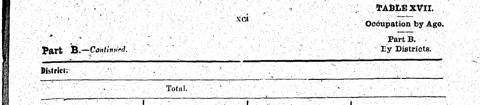

BOTTOM

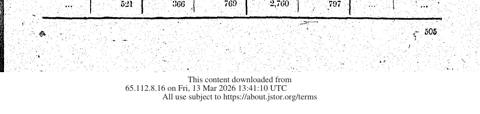

section(roman top)=91 · top=xci(roman) · bottom=505(arabic) · data_table

5bdff8f91941b96f6de57183a36eb09c02dc6e4d.png

p.187 volume (arabic, bottom) was 89 → 187

TOP

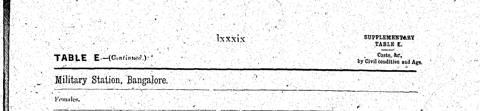

BOTTOM

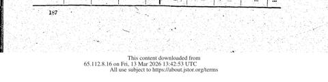

section(roman top)=89 · top=lxxxix(roman) · bottom=187(arabic) · data_table

609394e447165874efe9233e06e241f63f165b81.png

p.134 volume (arabic, bottom) was 36 → 134

TOP

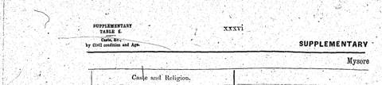

BOTTOM

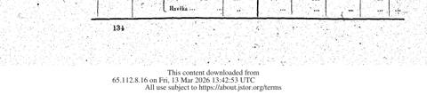

section(roman top)=36 · top=xxxvi(roman) · bottom=134(arabic) · data_table

62c835fa5b7ca90fa03867606a0b33006b3b46a6.png

p.352 volume (arabic, bottom) was 36 → 352

TOP

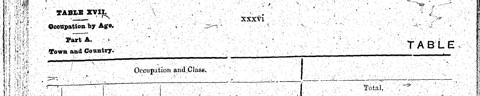

BOTTOM

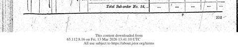

section(roman top)=36 · top=xxxvi(roman) · bottom=352(arabic) · data_table

63f73fd8487e40e0251eacaf236581eec5dbf310.png

p.446 volume (arabic, bottom) was 32 → 446

TOP

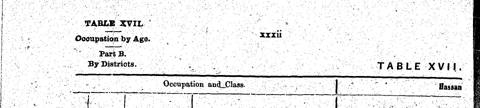

BOTTOM

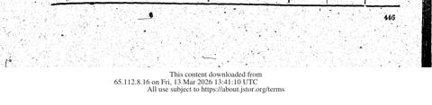

section(roman top)=32 · top=xxxii(roman) · bottom=446(arabic) · data_table

60c9320f4c45e2365af5a6afbc2165f97475683c.png